# 数据科学导论 学生评教影响因素分析

文锦鸿222024303250203

2026.10

# 1. 探索性分析

## 数据

实际教学中常遇到这样的情况：某老师给两个不同的班级上《数学分析》，假设他对每个班的付出基本相同，但最终两个班的**学生评教**（Student Evaluation of Teaching，SET）成绩却可能差别较大。这是因为有太多的非教师因素会影响学生评教成绩，如班级人数、学生类别等。

数据集SET来源于某学院2002-2004年的学生评教记录，共340门课程。因变量是score（课程评分，单位：分），是学生打分的平均值。可能的影响因素包括：title（教师职称：助理教授、副教授、正教授）、gender（教师性别：男、女）、student（学生类别：MBA、本科生、研究生）、year（年份：2002、2003、2004）、semester（学期：秋季、春季）以及size（班级人数，单位：人）。

读入数据并部分展示如下：

```r
library(tidyverse)
setwd("C:/Users/wendashi/Desktop/ids_hw1")
d = read.csv("SET.csv", header = T, stringsAsFactors = TRUE)
head(d)
```

```
##    title gender student year semester size score
## 1 副教授     女     MBA 2002     秋季  114 3.175
## 2 副教授     女     MBA 2002     秋季   88 3.523
## 3 副教授     女     MBA 2003     秋季   83 4.458
## 4 副教授     女     MBA 2002     秋季   66 3.470
## 5 副教授     女     MBA 2003     秋季   46 4.630
## 6 副教授     女     MBA 2004     秋季   45 4.511
```

将数值型的类别变量year转为因子，并指定水平顺序（2002 < 2003 < 2004）：

```r
d$year <- factor(d$year, levels = c(2002, 2003, 2004))
```

## 基本统计量

```r
summary(d)
```

```
##       title     gender     student      year     semester        size
##  副教授  :131   男:281   MBA   :132   2002:165   春季: 85   Min.   :  3.00
##  正教授  :151   女: 59   本科生: 64   2003: 83   秋季:255   1st Qu.: 18.00
##  助理教授: 58            研究生:144   2004: 92              Median : 33.50
##                                                             Mean   : 39.88
##                                                             3rd Qu.: 54.00
##                                                             Max.   :136.00
##      score
##  Min.   :2.556
##  1st Qu.:4.043
##  Median :4.356
##  Mean   :4.269
##  3rd Qu.:4.626
##  Max.   :5.000
```

## 课程评分分布

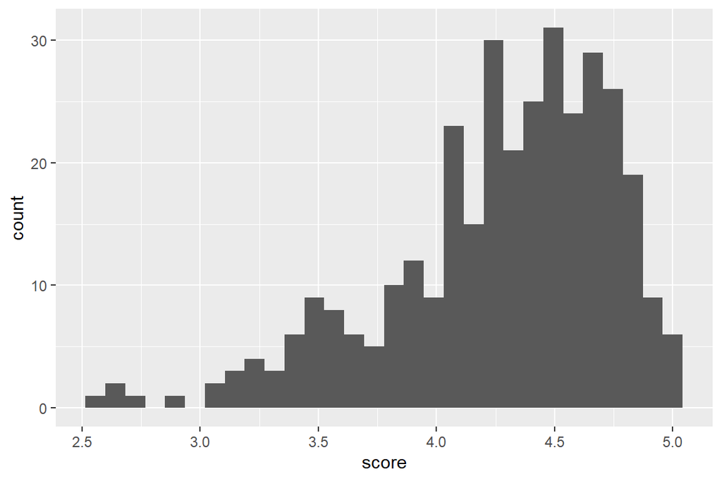

```r
ggplot(data = d, aes(x = score)) +
  geom_histogram(bins = 30)
```

直方图显示：课程评分呈现出左偏（负偏态），表示多数课程评分较高，但有少数低分课程形成长尾，整体均值被低分端拉低。

## 双变量分析

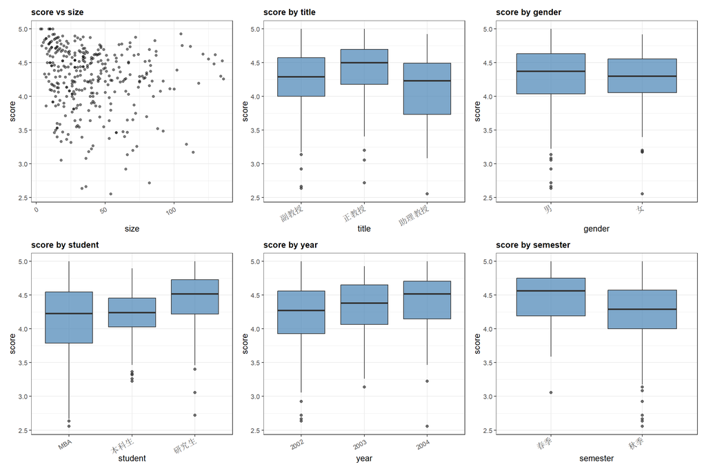

```r
library(patchwork)       # 用于拼图

# 统一主题，避免每张图重复写
th <- theme_bw(base_size = 10) +
  theme(plot.title = element_text(face = "bold", size = 10),
        axis.text.x = element_text(angle = 30, hjust = 1))

# 连续 vs 连续 → 散点图
p1 <- ggplot(d, aes(size, score)) +
  geom_point(alpha = .5, size = 1.2) +
  labs(title = "score vs size", x = "size", y = "score") +
  th

# 分类 vs 连续 → 箱线图（5 张结构一样，只有 x 变量不同）
p2 <- ggplot(d, aes(title, score)) +
  geom_boxplot(fill = "steelblue", alpha = .7) +
  labs(title = "score by title", x = "title", y = "score") +
  th

p3 <- ggplot(d, aes(gender, score)) +
  geom_boxplot(fill = "steelblue", alpha = .7) +
  labs(title = "score by gender", x = "gender", y = "score") +
  th

p4 <- ggplot(d, aes(student, score)) +
  geom_boxplot(fill = "steelblue", alpha = .7) +
  labs(title = "score by student", x = "student", y = "score") +
  th

p5 <- ggplot(d, aes(year, score)) +
  geom_boxplot(fill = "steelblue", alpha = .7) +
  labs(title = "score by year", x = "year", y = "score") +
  th

p6 <- ggplot(d, aes(semester, score)) +
  geom_boxplot(fill = "steelblue", alpha = .7) +
  labs(title = "score by semester", x = "semester", y = "score") +
  th

# 排版两行三列
(p1 | p2 | p3) / (p4 | p5 | p6)
```

结果显示：

（2）课程评分中位数随职称呈现正教授最高、副教授居中、助理教授最低的特征，初步判断课程评分与教师职称可能存在关联；

（3）男性课程评分中位数略高于女性，但是女性样本较少只有59门，初步判断教师性别对课程评分影响不大，关联性不高；

（4）课程评分中位数随学生类别呈现研究生最高，本科生和MBA相当的特征，初步判断课程评分与学生类别可能存在关联；

（5）课程评分随年份增长呈递增趋势，初步判断课程评分与年份可能存在关联；

探索性分析显示，课程评分与班级人数、教师职称、教师性别、学生类别、评分年份及开课学期均存在一定的描述性关联。后续拟构建线性回归模型，在控制相关因素的基础上进一步检验这些变量与课程评分的关系。

# 2. 全样本线性回归（解释性建模）

使用全样本构建线性回归模型，重点从定量和可解释角度描述各自变量对课程评分的影响程度。

## 2.1 模型设定与基准组

R 在估计线性模型时，会把每个分类变量的第一个水平作为基准组。因子的默认水平顺序由字符编码决定，未必是想要的那一组，因此建模前手动固定基准组：职称以助理教授为基准，性别以男教师为基准，学生类别以 MBA 为基准，学期以秋季为基准；年份以 2002 年为基准。

```r
d$title    <- factor(d$title,    levels = c("助理教授", "副教授", "正教授"))
d$gender   <- factor(d$gender,   levels = c("男", "女"))
d$student  <- factor(d$student,  levels = c("MBA", "研究生", "本科生"))
d$semester <- factor(d$semester, levels = c("秋季", "春季"))

# 打印基准组，确认设置无误
cat("基准组：", levels(d$title)[1], "/", levels(d$gender)[1], "/",
    levels(d$student)[1], "/", levels(d$semester)[1], "/", levels(d$year)[1], "\n")
```

```
## 基准组： 助理教授 / 男 / MBA / 秋季 / 2002
```

## 2.2 主模型结果

```r
library(broom)
m1 <- lm(score ~ title + gender + student + year + semester + size, data = d)
summary(m1)
```

```
##
## Call:
## lm(formula = score ~ title + gender + student + year + semester +
##     size, data = d)
##
## Residuals:
##     Min      1Q  Median      3Q     Max
## -1.6826 -0.2488  0.0870  0.3068  0.8285
##
## Coefficients:
##                 Estimate Std. Error t value Pr(>|t|)
## (Intercept)    3.9106795  0.0895336  43.678  < 2e-16 ***
## title副教授    0.0808020  0.0712162   1.135 0.257366
## title正教授    0.2607340  0.0849243   3.070 0.002317 **
## gender女       0.0165154  0.0672759   0.245 0.806231
## student研究生  0.2783592  0.0578522   4.812 2.28e-06 ***
## student本科生  0.0825050  0.0681743   1.210 0.227066
## year2003       0.1429366  0.0603994   2.367 0.018533 *
## year2004       0.2269308  0.0578366   3.924 0.000106 ***
## semester春季   0.0086251  0.0859299   0.100 0.920108
## size          -0.0005755  0.0010539  -0.546 0.585419
## ---
## Signif. codes:  0 '***' 0.001 '**' 0.01 '*' 0.05 '.' 0.1 ' ' 1
##
## Residual standard error: 0.4397 on 330 degrees of freedom
## Multiple R-squared:  0.1715, Adjusted R-squared:  0.1489
## F-statistic: 7.589 on 9 and 330 DF,  p-value: 3.995e-10
```

```r
tidy(m1, conf.int = TRUE) |> knitr::kable(digits = 4)
```

| term | estimate | std.error | statistic | p.value | conf.low | conf.high |
| --- | --- | --- | --- | --- | --- | --- |
| (Intercept) | 3.9107 | 0.0895 | 43.6783 | 0.0000 | 3.7346 | 4.0868 |
| title副教授 | 0.0808 | 0.0712 | 1.1346 | 0.2574 | -0.0593 | 0.2209 |
| title正教授 | 0.2607 | 0.0849 | 3.0702 | 0.0023 | 0.0937 | 0.4278 |
| gender女 | 0.0165 | 0.0673 | 0.2455 | 0.8062 | -0.1158 | 0.1489 |
| student研究生 | 0.2784 | 0.0579 | 4.8116 | 0.0000 | 0.1646 | 0.3922 |
| student本科生 | 0.0825 | 0.0682 | 1.2102 | 0.2271 | -0.0516 | 0.2166 |
| year2003 | 0.1429 | 0.0604 | 2.3665 | 0.0185 | 0.0241 | 0.2618 |
| year2004 | 0.2269 | 0.0578 | 3.9237 | 0.0001 | 0.1132 | 0.3407 |
| semester春季 | 0.0086 | 0.0859 | 0.1004 | 0.9201 | -0.1604 | 0.1777 |
| size | -0.0006 | 0.0011 | -0.5460 | 0.5854 | -0.0026 | 0.0015 |

```r
cat("R² =", round(summary(m1)$r.squared, 3),
    "；调整 R² =", round(summary(m1)$adj.r.squared, 3), "\n")
```

```
## R² = 0.171 ；调整 R² = 0.149
```

上表为全样本模型的估计结果。模型整体解释了课程评分约 17% 的变异（R² = 0.171，调整 R² = 0.149），说明评分的绝大部分差异来自模型之外的课程与学生特征。

在控制其他因素后，有可靠影响的因素主要有三类。

（2）学生类别。研究生课程的评分比 MBA 高 0.278 分（p < 0.001），是分类变量中系数最大的一个；本科生比 MBA 高 0.083 分，但不显著（p = 0.227）。

（3）年份。评分逐年上升，2003 年比 2002 年高 0.143 分（p = 0.019），2004 年高 0.227 分（p < 0.001）。

教师性别（0.017，p = 0.806）与开课学期（0.009，p = 0.920）的系数都接近 0 且不显著，说明在现有样本下未发现它们与课程评分的可靠关联。“不显著”不等于“没有影响”，例如由女教师承担的课程只有 59 门，统计功效有限。

班级人数的线性系数为 −0.0006（p = 0.585），与第 1 节看到的负相关不一致，原因在 2.4 中说明。

截距 3.911 表示基准组（助理教授、男教师、MBA、2002 年秋季、班额为 0）的拟合评分。班额为 0 只是外推，截距本身没有实际含义，仅作为各系数比较的起点。

## 2.3 班级人数的影响是否为非线性

第 1 节的散点图显示，人数与评分的关系不像一条直线：中等规模的班级评分偏低，超大班的评分反而回升。为此在主模型中加入班级人数的平方项进行检验。

```r
d$size2 <- d$size^2
m2 <- lm(score ~ title + gender + student + year + semester + size + size2, data = d)
m3 <- lm(score ~ title + gender + student + year + semester + log(size), data = d)

# 嵌套模型检验：m2 比 m1 多的 size² 这一项值不值得加
anova(m1, m2)
```

```
## Analysis of Variance Table
##
## Model 1: score ~ title + gender + student + year + semester + size
## Model 2: score ~ title + gender + student + year + semester + size + size2
##   Res.Df    RSS Df Sum of Sq      F  Pr(>F)
## 1    330 63.802
## 2    329 62.343  1    1.4584 7.6961 0.00585 **
## ---
## Signif. codes:  0 '***' 0.001 '**' 0.01 '*' 0.05 '.' 0.1 ' ' 1
```

```r
# 二次模型与对数模型中人数项的系数
sm2 <- tidy(m2) |> dplyr::filter(term %in% c("size", "size2")) |> as.data.frame()
sm2$estimate  <- format(round(sm2$estimate, 7),   scientific = FALSE, drop0trailing = TRUE)
sm2$std.error <- format(signif(sm2$std.error, 4), scientific = FALSE, drop0trailing = TRUE)
sm2$statistic <- round(sm2$statistic, 3)
sm2$p.value   <- round(sm2$p.value, 4)
knitr::kable(sm2)
```

| term | estimate | std.error | statistic | p.value |
| --- | --- | --- | --- | --- |
| size | -0.0086005 | 0.003075 | -2.797 | 0.0055 |
| size2 | 0.0000675 | 0.00002433 | 2.774 | 0.0058 |

```r
sm3 <- tidy(m3) |> dplyr::filter(term == "log(size)") |> as.data.frame()
sm3$estimate  <- format(round(sm3$estimate, 6),   scientific = FALSE, drop0trailing = TRUE)
sm3$std.error <- format(signif(sm3$std.error, 4), scientific = FALSE, drop0trailing = TRUE)
sm3$statistic <- round(sm3$statistic, 3)
sm3$p.value   <- round(sm3$p.value, 4)
knitr::kable(sm3)
```

| term | estimate | std.error | statistic | p.value |
| --- | --- | --- | --- | --- |
| log(size) | -0.085042 | 0.04003 | -2.125 | 0.0344 |

```r
# 三个模型横向比较
cmp <- data.frame(模型 = c("m1 线性", "m2 二次", "m3 对数"))
cmp$R2     <- round(c(summary(m1)$r.squared,     summary(m2)$r.squared,     summary(m3)$r.squared), 3)
cmp$调整R2 <- round(c(summary(m1)$adj.r.squared, summary(m2)$adj.r.squared, summary(m3)$adj.r.squared), 3)
cmp$AIC    <- round(c(AIC(m1), AIC(m2), AIC(m3)), 2)
cmp$BIC    <- round(c(BIC(m1), BIC(m2), BIC(m3)), 2)
knitr::kable(cmp, row.names = FALSE)
```

| 模型 | R2 | 调整R2 | AIC | BIC |
| --- | --- | --- | --- | --- |
| m1 线性 | 0.171 | 0.149 | 418.00 | 460.12 |
| m2 二次 | 0.190 | 0.166 | 412.14 | 458.09 |
| m3 对数 | 0.182 | 0.160 | 413.69 | 455.81 |

```r
# 二次项系数与拐点
co <- coef(m2)
cat("size 一次项 =", round(co["size"], 6), "；size² 二次项 =", signif(co["size2"], 4), "\n")
```

```
## size 一次项 = -0.0086 ；size² 二次项 = 6.75e-05
```

```r
cat("拐点 =", round(-co["size"] / (2 * co["size2"]), 1), "人\n")
```

```
## 拐点 = 63.7 人
```

```r
# 不同人数下 size 项对评分的贡献
s <- c(3, 20, 40, 60, 80, 100, 136)
data.frame(人数 = s, 贡献 = round(co["size"] * s + co["size2"] * s^2, 3)) |>
  knitr::kable(row.names = FALSE)
```

| 人数 | 贡献 |
| --- | --- |
| 3 | -0.025 |
| 20 | -0.145 |
| 40 | -0.236 |
| 60 | -0.273 |
| 80 | -0.256 |
| 100 | -0.185 |
| 136 | 0.079 |

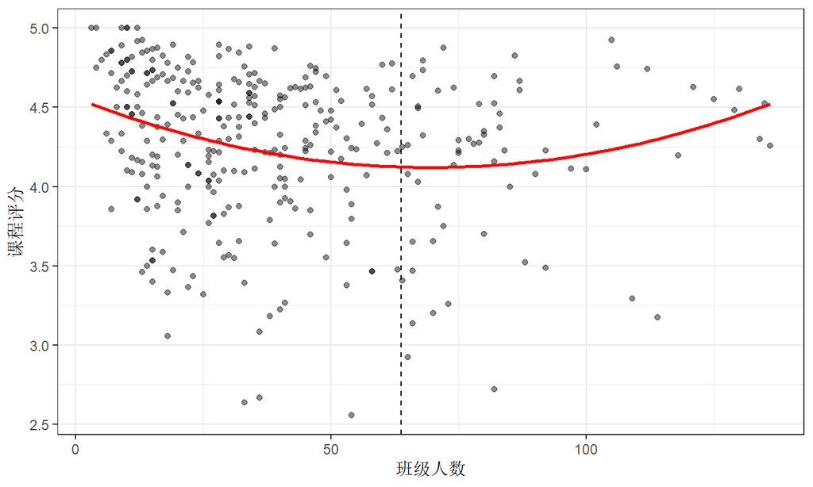

```r
ggplot(d, aes(size, score)) +
  geom_point(alpha = .45) +
  geom_smooth(method = "lm", formula = y ~ poly(x, 2), se = FALSE, color = "red") +
  geom_vline(xintercept = -co["size"] / (2 * co["size2"]), linetype = 2) +
  labs(x = "班级人数", y = "课程评分") +
  theme_bw()
```

```r
# 按人数分组的平均分，用于对照上图中二次曲线的形状
grp <- cut(d$size, breaks = c(0, 20, 35, 55, 80, 100, 137),
           labels = c("≤20", "21–35", "36–55", "56–80", "81–100", ">100"))
data.frame(人数分组 = levels(grp),
           课程数   = as.vector(table(grp)),
           平均分   = round(as.vector(tapply(d$score, grp, mean)), 3)) |>
  knitr::kable(row.names = FALSE)
```

| 人数分组 | 课程数 | 平均分 |
| --- | --- | --- |
| ≤20 | 98 | 4.415 |
| 21–35 | 88 | 4.268 |
| 36–55 | 73 | 4.168 |
| 56–80 | 50 | 4.149 |
| 81–100 | 17 | 4.165 |
| >100 | 14 | 4.345 |

```r
# 未控制其他变量时（即图中那条红色曲线）的最低点
q_raw <- lm(score ~ size + I(size^2), data = d)
qb    <- coef(q_raw)
x_min <- -qb[2] / (2 * qb[3])
cat("未控制其他变量时，曲线在", round(x_min, 1), "人处最低，约",
    round(predict(q_raw, data.frame(size = x_min)), 2), "分\n")
```

```
## 未控制其他变量时，曲线在 69.6 人处最低，约 4.12 分
```

方差分析显示，加入班级人数的平方项后残差平方和显著下降（F(1, 329) = 7.70，p = 0.006），说明人数的影响确实不是线性的。二次模型中一次项系数为 −0.0086（p = 0.006），二次项系数为 0.0000675（p = 0.006），一负一正说明曲线开口向上，拐点约在 64 人：人数少于 64 人时评分随人数增加而下降，超过之后转为上升。按这个模型计算，人数效应（相对人数为 0 的起点）在 20 人时为 −0.15 分、60 人时为 −0.27 分、136 人时为 +0.08 分，也就是从 20 人到 60 人评分再降约 0.12 分，从 60 人到 136 人反而回升约 0.35 分。

前面的散点图把二次拟合曲线叠在数据上（红色曲线为未控制其他变量的拟合，仅用于展示形状）。未控制其他变量时，曲线在约 70 人处最低（约 4.12 分），向两端上升，这与控制其他因素后得到的拐点（63.7 人）位置接近。这一形状与实际分组均值吻合：56 到 80 人组的平均分最低（4.149），100 人以上组回升到 4.345，接近 20 人以下组的 4.415。

改用 log(size) 的模型得到方向一致的结论（系数 −0.085，p = 0.034），且参数个数与线性模型相同，调整 R² 由 0.149 提高到 0.160。模型比较的结果需要注意：AIC 最支持二次模型（412.14），BIC 最支持对数模型（455.81），两者并不一致（BIC 对多一个参数的惩罚更重），但两个标准都认为线性模型最差。因此可以确定“人数的影响不是线性的”。

## 2.4 人数效应与学生类别的混杂

为检验人数的效应是否被学生类别吸收，去掉 student 变量重新估计同一模型。

```r
m1_nostu <- lm(score ~ title + gender + year + semester + size, data = d)
data.frame(
  模型 = c("含 student", "不含 student"),
  size系数 = round(c(coef(m1)["size"], coef(m1_nostu)["size"]), 4),
  t值 = round(c(summary(m1)$coefficients["size", 3], summary(m1_nostu)$coefficients["size", 3]), 3),
  p值 = round(c(summary(m1)$coefficients["size", 4], summary(m1_nostu)$coefficients["size", 4]), 4),
  R2 = round(c(summary(m1)$r.squared, summary(m1_nostu)$r.squared), 3)
) |> knitr::kable(row.names = FALSE)
```

| 模型 | size系数 | t值 | p值 | R2 |
| --- | --- | --- | --- | --- |
| 含 student | -0.0006 | -0.546 | 0.5854 | 0.171 |
| 不含 student | -0.0021 | -2.056 | 0.0405 | 0.113 |

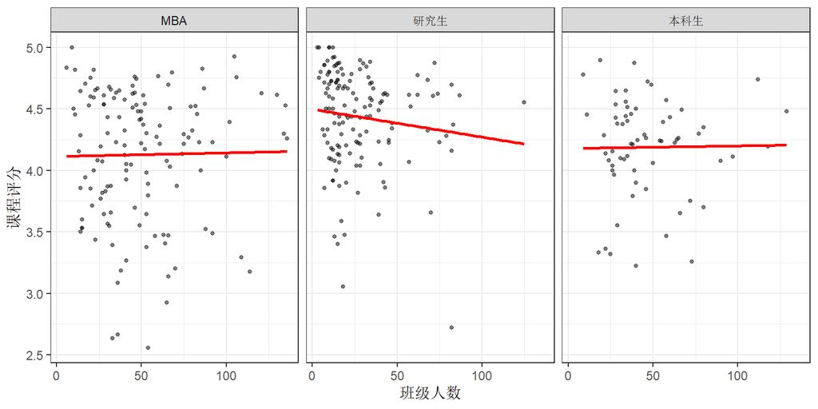

```r
ggplot(d, aes(size, score)) +
  geom_point(alpha = .5, size = 1) +
  geom_smooth(method = "lm", se = FALSE, color = "red") +
  facet_wrap(~ student) +
  labs(x = "班级人数", y = "课程评分") +
  theme_bw()
```

```r
# 各学生类别的课程数、平均班额、平均分，以及组内人数与评分的相关系数
grp_stu <- d |>
  dplyr::group_by(student) |>
  dplyr::summarise(课程数 = dplyr::n(),
                   平均班额 = round(mean(size), 1),
                   平均分 = round(mean(score), 3),
                   组内相关系数 = round(cor(size, score), 3))
knitr::kable(grp_stu)
```

| student | 课程数 | 平均班额 | 平均分 | 组内相关系数 |
| --- | --- | --- | --- | --- |
| MBA | 132 | 49.8 | 4.128 | 0.016 |
| 研究生 | 144 | 27.8 | 4.435 | -0.124 |
| 本科生 | 64 | 46.7 | 4.188 | 0.013 |

前面的对比表显示，去掉学生类别后，size 系数由 −0.0006（p = 0.585）变为 −0.0021，t 值为 −2.06，在 5% 水平上显著（p = 0.041），同时模型的 R² 由 0.171 降到 0.113。只有在不控制学生类别时，班级人数才表现得有影响。

MBA 课程平均 49.8 人、平均分 4.128，研究生课程平均只有 27.8 人、平均分 4.435。人数多的课往往是 MBA 课程，而 MBA 课程的评分本身偏低。把数据按学生类别分开画（见前面的分面图）后，三组的拟合线都接近水平（组内相关系数分别为 0.016、−0.124、0.013），说明在同一类学生内部，人数与评分几乎没有关系。

因此第 1 节看到的“人数越多评分越低”，很大程度上是“学生类别”在起作用，不能直接解释为班级规模导致评分下降。

## 2.5 学期效应为什么消失

```r
table(d$semester, d$title)
```

```
##
##        助理教授 副教授 正教授
##   秋季       58    131     66
##   春季        0      0     85
```

```r
table(d$semester, d$gender)
```

```
##
##         男  女
##   秋季 196  59
##   春季  85   0
```

```r
round(tapply(d$size,  d$semester, mean), 1)
```

```
## 秋季 春季
## 46.1 21.3
```

```r
round(tapply(d$score, d$semester, mean), 3)
```

```
##  秋季  春季
## 4.209 4.452
```

```r
sem_tab <- data.frame(
  控制变量 = c("仅学期", "+ 学生类别", "+ 学生类别、年份、人数",
               "+ 学生类别、年份、人数、职称、性别")
)
sem_tab$学期系数 <- round(c(
  coef(lm(score ~ semester, data = d))[2],
  coef(lm(score ~ semester + student, data = d))[2],
  coef(lm(score ~ semester + student + year + size, data = d))[2],
  coef(lm(score ~ semester + student + year + size + title + gender, data = d))[2]
), 4)
knitr::kable(sem_tab, row.names = FALSE)
```

| 控制变量 | 学期系数 |
| --- | --- |
| 仅学期 | 0.2428 |
| + 学生类别 | 0.1593 |
| + 学生类别、年份、人数 | 0.1756 |
| + 学生类别、年份、人数、职称、性别 | 0.0086 |

交叉表显示，春季学期的 85 门课全部由正教授承担，且全部为男教师；秋季学期包含 131 门副教授、58 门助理教授和 66 门正教授课程，59 门由女教师承担的课程也全部集中在秋季。也就是说，学期与职称、性别在数据中是结构性绑定的。再看班额：春季平均 21.3 人，秋季平均 46.1 人。

逐层加入控制变量可以看到学期系数如何变化：只放学期时为 0.243，控制学生类别后降到 0.159，再加入年份和人数后为 0.176，最后加入职称和性别后只剩 0.009 且不显著。春季的评分优势主要来自授课教师构成（正教授、男教师）和较小的班额，并不是开课季节本身。

由于春季不存在副教授和助理教授的课程，无法把季节的独立影响与教师构成完全分离。因此这个结果应理解为“控制教师构成后，学期没有剩余差异”，而不是“开课季节与评分无关”。

## 2.6 残差诊断与多重共线性

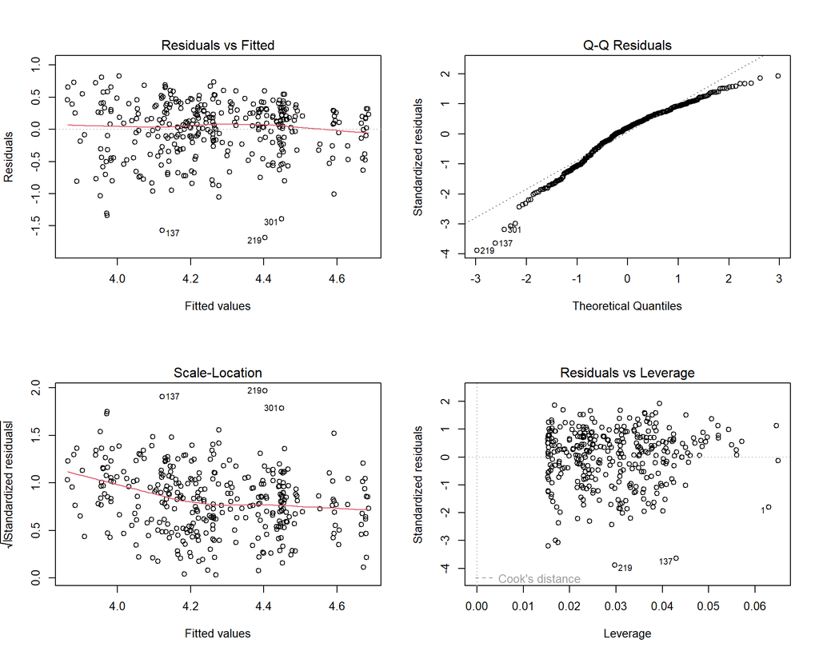

```r
par(mfrow = c(2, 2))
plot(m1)
```

```r
par(mfrow = c(1, 1))
```

```r
# 残差诊断的数值摘要
resid_m1 <- residuals(m1)
worst    <- order(resid_m1)[1:3]
cat("最大 Cook 距离 =", round(max(cooks.distance(m1)), 3), "\n")
```

```
## 最大 Cook 距离 = 0.06
```

```r
cat("|残差| 与拟合值的相关系数 =", round(cor(abs(resid_m1), fitted(m1)), 3), "\n")
```

```
## |残差| 与拟合值的相关系数 = -0.225
```

```r
cat("Shapiro-Wilk 正态性检验 p 值 =", signif(shapiro.test(resid_m1)$p.value, 3), "\n")
```

```
## Shapiro-Wilk 正态性检验 p 值 = 5.16e-09
```

```r
data.frame(行号 = worst, 残差 = round(resid_m1[worst], 2)) |>
  knitr::kable(row.names = FALSE)
```

| 行号 | 残差 |
| --- | --- |
| 219 | -1.68 |
| 137 | -1.57 |
| 301 | -1.39 |

正态 Q-Q 图的两端偏离对角线，左端偏离更明显，对应编号 219、137、301 的三门残差约 −1.4 至 −1.7 分的低分课程；整体残差近似对称但尾部略厚，因此正态性检验会被拒绝（Shapiro-Wilk 检验 p < 0.001）。在大样本下这不影响系数估计的一致性，但提示线性模型对极低分课程的解释力有限。

Cook 距离图中所有点都远低于常用的 0.5 警戒值，最大 Cook 距离仅为 0.06，说明不存在主导估计结果的强影响点，前面的系数结论是稳健的。

```r
if (requireNamespace("car", quietly = TRUE)) {
  knitr::kable(round(car::vif(m1), 3))
} else {
  message("未安装 car 包，vif 计算跳过；可先运行 install.packages('car')")
}
```

|  | GVIF | Df | GVIF^(1/(2*Df)) |
| --- | --- | --- | --- |
| title | 2.091 | 2 | 1.203 |
| gender | 1.142 | 1 | 1.068 |
| student | 1.293 | 2 | 1.066 |
| year | 1.056 | 2 | 1.014 |
| semester | 2.435 | 1 | 1.560 |
| size | 1.488 | 1 | 1.220 |

多重共线性方面，由于模型中有多个分类变量，car::vif() 返回的是 GVIF 而不是普通的 VIF，需要看最后一列 GVIF^(1/(2Df))。结果显示所有变量的 GVIF 都小于 5，其中最大的两个是开课学期（2.43）和教师职称（2.09），其余变量都在 1.5 以下，说明模型不存在严重的多重共线性。学期与职称偏高，与前面发现的“春季课程全部由正教授承担”一致。

## 2.7 本节小结

本节通过多元线性回归考察了各因素对课程评分的净影响，主要结论有三点： (1)职称的作用体现为“正教授与其他职称”之间的差距，副教授与助理教授并无显著差异； (2)学生类别的影响较大，研究生课程评分显著高于 MBA 课程； (3)评分存在逐年上升的趋势，而教师性别和开课学期在控制其他因素后没有可靠影响。

另外两类“单变量看起来有影响、控制后消失”的现象：班级人数的影响基本由学生类别解释，学期的影响则由授课教师构成解释。所以光比平均分不够，还得控制别的因素。

模型 R² 约为 0.17，解释力有限，评分的绝大部分差异来自课程难度、学生基础、教学方式等未纳入模型的因素。此外，部分交叉类别样本量偏小（如 2002 年的助理教授课程只有 20 门），加上评分存在 5 分的上限导致残差非正态，上述系数的精度和推断都应谨慎看待。

# 3. 预测性建模与评估

以预测为目标，将数据划分为训练集和测试集；在训练集上重新建模，并引入岭回归、Lasso 等正则化方法进行比较与选择，最终在测试集上评估模型的预测能力。

## 3.1 训练集与测试集的划分

与第 2 节不同，本节的目标是预测而不是解释，因此先把数据分成互不重叠的两部分：训练集用于估计模型，测试集只在最后评估时使用。按 7:3 的比例随机划分，并用 set.seed(303250203) 固定随机数种子，保证结果可复现（该数值取自学号后 9 位；R 的种子取值上限为 2^31−1，完整学号超出范围）。

```r
set.seed(303250203)
n <- nrow(d)
idx <- sample(n, size = round(0.7 * n))
train <- d[idx, ]
test  <- d[-idx, ]

cat("训练集", nrow(train), "门；测试集", nrow(test), "门\n")
```

```
## 训练集 238 门；测试集 102 门
```

```r
cat("训练集平均分", round(mean(train$score), 3),
    "；测试集平均分", round(mean(test$score), 3), "\n")
```

```
## 训练集平均分 4.245 ；测试集平均分 4.327
```

划分结果为训练集 238 门、测试集 102 门，两部分的平均分分别为 4.245 和 4.327，分别位于全样本均值 4.269 的两侧，说明随机划分没有造成明显的样本偏差。

## 3.2 训练集上的模型估计

参与比较的有四类预测：一是训练集均值，即不看任何自变量、一律用训练集平均分去预测，作为“什么都不做”的基准；二是普通最小二乘（OLS），自变量与第 2 节主模型相同；三是岭回归（L2 惩罚）；四是 Lasso（L1 惩罚）。后两者用 10 折交叉验证选择惩罚参数 λ，需要先把因子变量展开成设计矩阵。

```r
rmse <- function(actual, pred) sqrt(mean((actual - pred)^2))
mae  <- function(actual, pred) mean(abs(actual - pred))
r2   <- function(actual, pred) 1 - sum((actual - pred)^2) / sum((actual - mean(actual))^2)

fml <- score ~ title + gender + student + year + semester + size

# 基准：只用训练集均值预测
m_null <- lm(score ~ 1, data = train)

# 与第 2 节相同的设定，但只用训练集估计
m_train <- lm(fml, data = train)

# 正则化模型需要设计矩阵
library(glmnet)
x_train <- model.matrix(fml, data = train)[, -1]
x_test  <- model.matrix(fml, data = test)[, -1]
y_train <- train$score
y_test  <- test$score

set.seed(303250203)
cv_ridge <- cv.glmnet(x_train, y_train, alpha = 0, nfolds = 10)
set.seed(303250203)
cv_lasso <- cv.glmnet(x_train, y_train, alpha = 1, nfolds = 10)

cat("训练集 OLS 的 R² =", round(summary(m_train)$r.squared, 3), "\n")
```

```
## 训练集 OLS 的 R² = 0.184
```

```r
cat("岭回归 lambda.min =", signif(cv_ridge$lambda.min, 3),
    "；Lasso lambda.min =", signif(cv_lasso$lambda.min, 3), "\n")
```

```
## 岭回归 lambda.min = 0.0933 ；Lasso lambda.min = 0.0248
```

交叉验证选出的惩罚参数都很小（岭回归 λ = 0.0933，Lasso λ = 0.0248），说明数据并不需要很强的收缩。

## 3.3 测试集评估

把训练集上估计出的模型直接用于预测测试集的 102 门课程，计算 RMSE、MAE 和 R²。

```r
pred_null  <- predict(m_null, newdata = test)
pred_ols   <- predict(m_train, newdata = test)
pred_ridge <- as.numeric(predict(cv_ridge, s = "lambda.min", newx = x_test))
pred_lasso <- as.numeric(predict(cv_lasso, s = "lambda.min", newx = x_test))

perf <- data.frame(
  模型 = c("训练集均值", "OLS", "岭回归", "Lasso"),
  RMSE = round(c(rmse(y_test, pred_null), rmse(y_test, pred_ols),
                 rmse(y_test, pred_ridge), rmse(y_test, pred_lasso)), 4),
  MAE  = round(c(mae(y_test, pred_null), mae(y_test, pred_ols),
                 mae(y_test, pred_ridge), mae(y_test, pred_lasso)), 4),
  R2   = round(c(r2(y_test, pred_null), r2(y_test, pred_ols),
                 r2(y_test, pred_ridge), r2(y_test, pred_lasso)), 4)
)
knitr::kable(perf, row.names = FALSE)
```

| 模型 | RMSE | MAE | R2 |
| --- | --- | --- | --- |
| 训练集均值 | 0.4607 | 0.3733 | -0.0328 |
| OLS | 0.4404 | 0.3531 | 0.0564 |
| 岭回归 | 0.4382 | 0.3593 | 0.0655 |
| Lasso | 0.4408 | 0.3623 | 0.0544 |

```r
cat("OLS 预测值范围", round(range(pred_ols), 3),
    "；测试集实际范围", round(range(y_test), 3), "\n")
```

```
## OLS 预测值范围 3.829 4.684 ；测试集实际范围 2.72 5
```

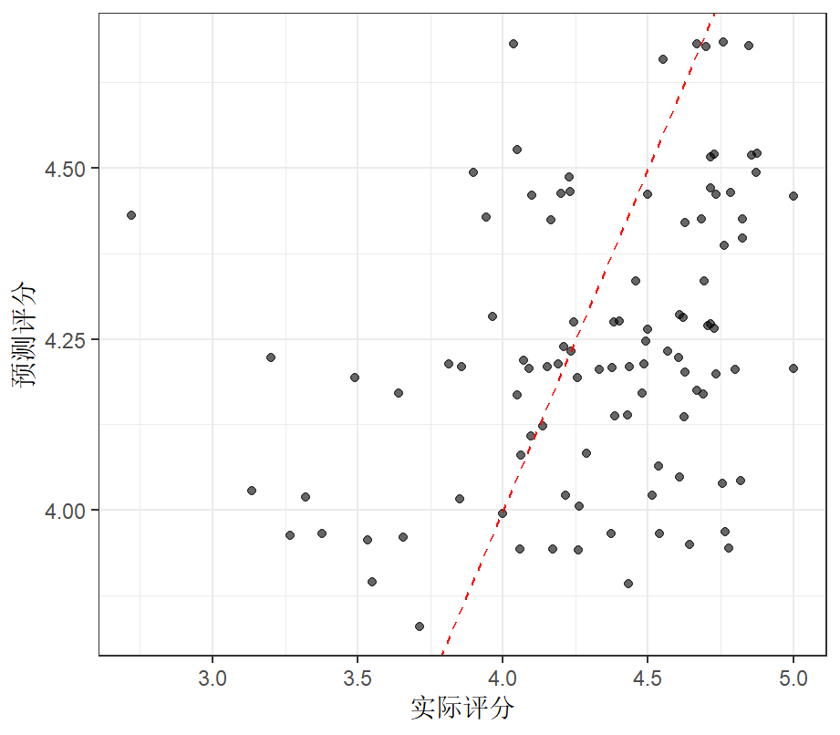

```r
ggplot(data.frame(实际 = y_test, 预测 = pred_ols), aes(实际, 预测)) +
  geom_point(alpha = .6) +
  geom_abline(slope = 1, intercept = 0, linetype = 2, color = "red") +
  labs(x = "实际评分", y = "预测评分") +
  theme_bw()
```

上面的评估表显示，三个模型的测试集 RMSE 非常接近：岭回归最小（0.4382），OLS 次之（0.4404），Lasso 略高（0.4408），三者相差不到 0.003 分；对应的 R² 在 0.054 至 0.066 之间。作为基准的“训练集均值”RMSE 为 0.4607，三个模型只比“一律预测平均分”好约 4%，并没有出现质的变化。

正则化的改善其实很有限：岭回归虽然数值上最好，但只比 OLS 低 0.002 分（约 0.5%），远小于随机划分本身带来的波动，第 3.5 节显示单次划分的 RMSE 标准差约为 0.03 分。另外，训练集 R² 为 0.184，而测试集 R² 只有 0.05 至 0.07，落差比全样本模型（0.17）明显。这既可能来自一定程度的过拟合，也可能只是因为测试集只有 102 门课程、R² 的抽样波动本来就大，3.5 节的重复划分支持后一种解释。两种情况下，正则化都没能把样本外的解释力提上去，这与第 2 节的结论一致：可用的自变量太少，预测上限由模型设定决定。

## 3.4 Lasso 选择出的变量

Lasso 的优势在于可以把不重要的变量系数压成 0，起到变量筛选的作用。

```r
co_lasso     <- coef(cv_lasso, s = "lambda.min")[-1, 1]
co_lasso_1se <- coef(cv_lasso, s = "lambda.1se")[-1, 1]

data.frame(变量 = names(co_lasso), 系数 = round(co_lasso, 4)) |>
  dplyr::filter(系数 != 0) |>
  knitr::kable(row.names = FALSE)
```

| 变量 | 系数 |
| --- | --- |
| title正教授 | 0.2062 |
| student研究生 | 0.1829 |
| year2004 | 0.1320 |
| semester春季 | 0.0106 |

```r
cat("设计矩阵共", length(co_lasso), "列；lambda.min 下保留", sum(co_lasso != 0),
    "个变量；lambda.1se 下保留", sum(co_lasso_1se != 0), "个变量\n")
```

```
## 设计矩阵共 9 列；lambda.min 下保留 4 个变量；lambda.1se 下保留 0 个变量
```

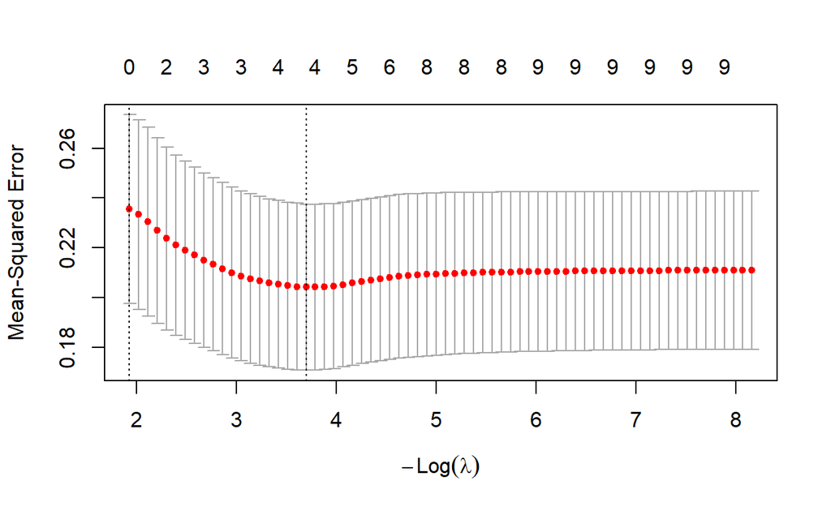

```r
plot(cv_lasso)
```

上图是 Lasso 的交叉验证曲线，横轴为 −log(λ)、纵轴为交叉验证均方误差，两条竖线分别对应 lambda.min 与 lambda.1se；横轴上方标出的是每个 λ 下被保留的非零变量个数。 在 λ = lambda.min 下，Lasso 从 9 个设计矩阵列中只保留了 4 个：正教授、研究生、2004 年和春季；副教授、女教师、本科生、2003 年和班级人数五项的系数被压成 0。 若改用更严厉的 lambda.1se，则一个变量都不保留，预测退化为训练集均值。保留的变量大多与第 2 节吻合：正教授、研究生和 2004 年都是显著的，被剔除的班级人数也确实不显著；但 2003 年在第 2 节显著（p = 0.019）却被剔除，学期不显著却被保留，说明变量筛选与显著性检验并不总是一致。

由于 glmnet 默认对自变量做标准化，上表中的系数是标准化尺度上的数值，只能用于比较相对重要性，不能直接读成“多少分”。另外，“春季”与“正教授”在数据中高度相关（春季课程全部由正教授承担），当两个强相关变量同时存在时，Lasso 保留哪一个带有相当的任意性，因此不宜把“保留春季而剔除 2003 年”当作实质性的结论。

## 3.5 稳健性：换一次划分会不会改变结论

3.3 的结论建立在一次随机划分上，排名可能带有偶然性。为此重复 200 次随机划分，每次重新估计三个模型，比较测试集 RMSE 的平均水平。

```r
R <- 200
res <- matrix(NA_real_, R, 4)
for (s in seq_len(R)) {
  set.seed(s)
  ii  <- sample(n, round(0.7 * n))
  tr  <- d[ii, ]
  te  <- d[-ii, ]
  xtr <- model.matrix(fml, data = tr)[, -1]
  xte <- model.matrix(fml, data = te)[, -1]
  fit_ols <- lm(fml, data = tr)
  set.seed(s)
  cvr <- cv.glmnet(xtr, tr$score, alpha = 0, nfolds = 5)
  set.seed(s)
  cvl <- cv.glmnet(xtr, tr$score, alpha = 1, nfolds = 5)
  res[s, ] <- c(
    rmse(te$score, rep(mean(tr$score), nrow(te))),
    rmse(te$score, predict(fit_ols, te)),
    rmse(te$score, as.numeric(predict(cvr, s = "lambda.min", newx = xte))),
    rmse(te$score, as.numeric(predict(cvl, s = "lambda.min", newx = xte)))
  )
}
colnames(res) <- c("训练集均值", "OLS", "岭回归", "Lasso")
data.frame(模型 = colnames(res),
           平均RMSE = round(colMeans(res), 4),
           标准差   = round(apply(res, 2, sd), 4)) |>
  knitr::kable(row.names = FALSE)
```

| 模型 | 平均RMSE | 标准差 |
| --- | --- | --- |
| 训练集均值 | 0.4724 | 0.0345 |
| OLS | 0.4463 | 0.0306 |
| 岭回归 | 0.4455 | 0.0318 |
| Lasso | 0.4446 | 0.0318 |

```r
win <- apply(res[, 2:4], 1, which.min)
cat("三种方法的胜出次数：OLS", sum(win == 1), "；岭回归", sum(win == 2), "；Lasso", sum(win == 3), "\n")
```

```
## 三种方法的胜出次数：OLS 51 ；岭回归 44 ；Lasso 105
```

```r
cat("Lasso 减 OLS 的平均差 =", round(mean(res[, "Lasso"] - res[, "OLS"]), 4),
    "；差值范围", round(min(res[, "Lasso"] - res[, "OLS"]), 4), "至",
    round(max(res[, "Lasso"] - res[, "OLS"]), 4), "\n")
```

```
## Lasso 减 OLS 的平均差 = -0.0017 ；差值范围 -0.0205 至 0.0278
```

200 次划分的结果是：OLS 平均 RMSE 为 0.4463，岭回归 0.4455，Lasso 0.4446，三者相差不到 0.002 分，而单次划分之间的标准差约为 0.03 分。三种方法的差异远小于随机划分带来的波动：在 200 次划分中，OLS 胜出 51 次、岭回归 44 次、Lasso 105 次，胜负可以随意翻转。因此不能认为正则化带来了实质性的预测提升，3.3 中“岭回归略好”也只是某一次划分的结果。

## 3.6 本节小结

本节按 7:3 划分训练集与测试集，在训练集上重新估计了 OLS、岭回归和 Lasso，并在测试集上评估。

主要结论有两点： （1）四类预测中，OLS、岭回归和 Lasso 的测试集 RMSE 都在 0.438 至 0.441 分之间，只比“一律预测平均分”的 0.461 分好约 4%，测试集 R² 只有 0.05 至 0.07，明显低于第 2 节全样本的 0.17。 （2）正则化在这份数据上没有带来实质改善：三种方法的差异不到 0.003 分，远小于随机划分带来的波动（标准差约 0.03 分），重复 200 次划分也显示三种方法的胜负可以随意翻转。 预测精度的上限取决于手上有哪些变量。第 2 节的六个自变量只能解释约 17% 的评分差异，换用任何估计方法都无法突破这个上限。若想真正提高预测能力，需要引入课程难度、学生基础、教师授课风格等模型之外的变量；而这已超出本文的数据范围。